# Was 2025 a Heavy-Ball Year? Exit Velocity, Drag, and Ball Mass

A look at a friend’s question with Statcast data, 2017–2026

Author

Jim Albert

Published

November 7, 2026

## The question

A friend sent this note, prompted by the work on in-play home run rates and the “ball effect”:

> Here’s an interesting related question I think about sometimes: last year (2025) exit speeds were up relative to surrounding seasons, looking at league mean and 90th %ile, ~.5 mph higher than ’24 and ’26 which look similar to one another. It’s kind of an expensive model to try to control for all the individual players to determine how much of that we think is the ball and how much we think could be due to turnover in player population (eg, fewer Judge PA in ’26) but it seems overwhelmingly likely that it’s mostly the ball. I believe variation in the ball is very low dimensional; eg I think most of the variation we see can be explained in terms of ball inertia — when the ball gets heavier EVs are suppressed, but batted balls travel further when they get to higher EVs. 2025 may have been a heavy ball year. I think a lot of the variability in ball behavior that gets attributed to drag coefficient is actually due to ball mass, which we typically assume is fixed when estimating drag coefficient.

There are several testable claims here:

1. The 2025 rise in exit velocity is mostly the ball, not turnover in the hitter population.
2. Variation in the ball is low-dimensional.
3. Ball mass works in two directions: a heavier ball comes off the bat slower but carries farther for a given exit velocity.
4. 2025 was a heavy-ball year.

This document looks at each with data already in hand.

```r
library(dplyr)
library(tidyr)
library(ggplot2)
library(ggrepel)
library(knitr)
theme_set(theme_minimal(base_size = 12))
navy <- "#1a3a5c"; red <- "#b52020"

sc_dir <- "~/Library/CloudStorage/Dropbox/STATCAST/data"
```

## Data

Four sources are used:

- **Batted balls, 2015–2026** (`bip_2015_2026.rds`, the extract from the in-play home run analysis). It gives each batter’s exit velocities by season. Bunts are removed.
- **Bat tracking, 2024–2026.** Bat speed, exit velocity and pitch speed for balls in play on competitive swings (bat speed of at least 50 mph).
- **Pitch trajectories, 2017–2026.** The fitted velocity and acceleration of every four-seam fastball, which measure how fast the pitched ball loses speed to drag.
- **The Bayesian ball effects** (`blog_results.rds`, from `bayesian_ball_effect.qmd`). For each season, $\delta_t$ is the change in the log odds of a home run for the same batted ball (same exit velocity, launch angle, park and time of year) from the previous season. It measures carry.

The bat-tracking and pitch-trajectory summaries come from the full Statcast files. To keep rendering fast, they are saved in `ball_season_summaries.csv`. The function below rebuilds that file from the Statcast files if it is missing.

```r
season_summary <- function(yr) {
  x <- readr::read_csv(file.path(sc_dir, paste0("statcast", yr, ".csv")),
                       col_select = any_of(c("game_type", "type", "pitch_type",
                                             "vx0", "vy0", "vz0", "ax", "ay", "az",
                                             "release_speed", "launch_speed",
                                             "bat_speed", "des")),
                       show_col_types = FALSE, guess_max = 100000) |>
    filter(game_type == "R")
  # drag deceleration divided by speed squared, for four-seamers (x 10^4)
  ff <- x |>
    filter(pitch_type == "FF") |>
    filter(!is.na(vx0), !is.na(vy0), !is.na(vz0), !is.na(ax), !is.na(ay), !is.na(az)) |>
    mutate(v = sqrt(vx0^2 + vy0^2 + vz0^2),
           k = 1e4 * -(vx0 * ax + vy0 * ay + vz0 * (az + 32.174)) / v / v^2)
  out <- tibble(season = yr, n_ff = nrow(ff), ff_velo = mean(ff$release_speed, na.rm = TRUE),
                drag_k_mean = mean(ff$k), drag_k_median = median(ff$k))
  if ("bat_speed" %in% names(x) && sum(!is.na(x$bat_speed)) > 1000) {
    bt <- x |>
      filter(type == "X", !is.na(bat_speed), !is.na(launch_speed), !is.na(release_speed),
             bat_speed >= 50, !grepl("bunt", des, ignore.case = TRUE)) |>
      mutate(q = (launch_speed - bat_speed) / (0.92 * release_speed + bat_speed))
    out <- out |>
      mutate(n_bt = nrow(bt), bat_speed = mean(bt$bat_speed), ev_bt = mean(bt$launch_speed),
             q90 = quantile(bt$q, 0.90), q97 = quantile(bt$q, 0.97))
  }
  out
}

if (file.exists("ball_season_summaries.csv")) {
  summ <- read.csv("ball_season_summaries.csv")
} else {
  summ <- bind_rows(lapply(2017:2026, season_summary))
  write.csv(summ, "ball_season_summaries.csv", row.names = FALSE)
}
```

## Claim 1: Is it player turnover?

Controlling for individual hitters does not need an expensive model. A simple paired comparison does it: compare each batter with himself in consecutive seasons. The table uses batters with at least 50 balls in play in both seasons, weights each batter’s change by the inverse of its sampling variance, and compares the result with the league-wide change.

```r
bip <- readRDS("bip_2015_2026.rds") |> filter(!is.na(launch_speed), !bunt)
league <- bip |>
  group_by(season = game_year) |>
  summarise(mean_ev = mean(launch_speed), p90_ev = quantile(launch_speed, 0.9),
            .groups = "drop") |>
  mutate(d_mean = mean_ev - lag(mean_ev), d_p90 = p90_ev - lag(p90_ev))
by_batter <- bip |>
  group_by(batter, game_year) |>
  summarise(n = n(), ev = mean(launch_speed), p90 = quantile(launch_speed, 0.9),
            .groups = "drop")
within <- by_batter |>
  inner_join(by_batter |> mutate(game_year = game_year - 1),
             by = c("batter", "game_year"), suffix = c("", "_next")) |>
  filter(n >= 50, n_next >= 50) |>
  mutate(w = 1 / (1 / n + 1 / n_next)) |>
  group_by(season = game_year + 1) |>
  summarise(batters = n(),
            w_mean = weighted.mean(ev_next - ev, w),
            w_se = sd(ev_next - ev) / sqrt(n()),
            w_p90 = weighted.mean(p90_next - p90, w), .groups = "drop")
turn <- league |> select(season, d_mean, d_p90) |> inner_join(within, by = "season")
turn |>
  transmute(Change = paste0(season - 1, "→", season),
            `League mean` = sprintf("%+.2f", d_mean),
            `Within-batter mean` = sprintf("%+.2f (%.2f)", w_mean, w_se),
            `League 90th %ile` = sprintf("%+.1f", d_p90),
            `Within-batter 90th %ile` = sprintf("%+.2f", w_p90),
            Batters = batters) |>
  kable(caption = "Season-to-season change in exit velocity (mph): league-wide and within the same batters (standard error in parentheses)")
```

Season-to-season change in exit velocity (mph): league-wide and within the same batters (standard error in parentheses)

| Change | League mean | Within-batter mean | League 90th %ile | Within-batter 90th %ile | Batters |
| --- | --- | --- | --- | --- | --- |
| 2015→2016 | +0.33 | +0.21 (0.08) | +0.4 | +0.28 | 368 |
| 2016→2017 | -1.16 | -1.25 (0.08) | -0.2 | -0.37 | 348 |
| 2017→2018 | +1.04 | +0.97 (0.09) | +0.2 | +0.05 | 355 |
| 2018→2019 | +0.33 | +0.24 (0.09) | +0.4 | +0.33 | 371 |
| 2019→2020 | -0.27 | -0.46 (0.11) | -0.1 | -0.51 | 311 |
| 2020→2021 | +0.31 | +0.31 (0.11) | +0.6 | +0.68 | 308 |
| 2021→2022 | -0.18 | -0.49 (0.08) | -0.4 | -0.59 | 376 |
| 2022→2023 | +0.43 | +0.26 (0.09) | +0.4 | +0.15 | 376 |
| 2023→2024 | -0.18 | -0.30 (0.09) | -0.2 | -0.30 | 385 |
| 2024→2025 | +0.52 | +0.40 (0.08) | +0.6 | +0.36 | 378 |
| 2025→2026 | -0.62 | -0.67 (0.08) | -0.7 | -0.77 | 372 |

```r
t25 <- turn |> filter(season == 2025); t26 <- turn |> filter(season == 2026)
```

The within-batter changes track the league changes closely. From 2024 to 2025 the same batters gained +0.40 mph on average (league: +0.52), and from 2025 to 2026 they lost 0.67 mph (league: -0.62). Turnover in the hitter population explains little of the 2025 bump. The friend’s instinct on claim 1 is right.

## Bat speed and collision efficiency

Statcast’s bat tracking, available since 2024, separates two things that both raise exit velocity: how fast hitters swing, and how efficiently the ball comes off the bat. A standard summary of the second is the **collision efficiency**,
$$q = \frac{\text{EV} - v_{\text{bat}}}{v_{\text{pitch}} + v_{\text{bat}}},$$
where $v_{\text{pitch}}$ is the pitch speed at the plate (taken here as 92% of release speed). With this definition, exit velocity is $\text{EV} = q\, v_{\text{pitch}} + (1 + q)\, v_{\text{bat}}$. Most batted balls are not squarely struck, so the table reports the 90th and 97th percentiles of $q$, which describe well-struck balls.

```r
bt <- summ |> filter(!is.na(bat_speed))
bt |>
  transmute(Season = as.character(season), `Balls in play` = format(n_bt, big.mark = ","),
            `Bat speed (mph)` = sprintf("%.2f", bat_speed),
            `Mean EV (mph)` = sprintf("%.2f", ev_bt),
            `q, 90th %ile` = sprintf("%.4f", q90),
            `q, 97th %ile` = sprintf("%.4f", q97)) |>
  kable(caption = "Bat speed, exit velocity and collision efficiency on competitive swings")
```

Bat speed, exit velocity and collision efficiency on competitive swings

| Season | Balls in play | Bat speed (mph) | Mean EV (mph) | q, 90th %ile | q, 97th %ile |
| --- | --- | --- | --- | --- | --- |
| 2024 | 112,420 | 71.32 | 88.62 | 0.2073 | 0.2259 |
| 2025 | 116,018 | 71.67 | 89.13 | 0.2079 | 0.2263 |
| 2026 | 117,263 | 71.90 | 88.68 | 0.2024 | 0.2222 |

```r
b <- function(yr, v) bt[[v]][bt$season == yr]
```

The table tells two different stories:

- **2024 to 2025.** Bat speed rose by 0.36 mph, and collision efficiency barely changed (0.2073 to 0.2079 at the 90th percentile). Since EV rises by about $1 + q \approx 1.2$ mph per mph of bat speed, faster swings account for about 0.43 mph of the 0.51 mph increase in mean EV. The ball came off the bat the same way.
- **2025 to 2026.** Bat speed rose again, but exit velocity fell, because collision efficiency dropped (0.2079 to 0.2024). By this measure, the unusual season is 2026, not 2025.

## Claim 2: Is the ball effect low-dimensional?

The pitched ball gives an independent measurement of the ball. For every four-seam fastball, Statcast’s trajectory fit gives the ball’s velocity and acceleration. Removing gravity, the component of the acceleration opposite the direction of motion is the drag deceleration, and
$$\frac{\text{drag deceleration}}{v^2} = \frac{\rho\, C_d\, A}{2\, m},$$
where $\rho$ is air density, $C_d$ the drag coefficient, $A$ the cross-sectional area and $m$ the ball’s mass. This measures $C_d/m$, not $C_d$ alone: a heavier ball decelerates less, just like a smoother one.

The question is whether the season-to-season changes in pitch drag line up with the season-to-season changes in batted-ball carry ($\delta_t$), which were estimated from completely different data: home runs on batted balls, given their exit velocity and launch angle.

```r
res <- readRDS("blog_results.rds")
delta <- res$full |> select(season = game_year, delta = mean)
dc <- summ |>
  arrange(season) |>
  mutate(drag_change = 100 * (drag_k_mean / lag(drag_k_mean) - 1)) |>
  inner_join(delta, by = "season") |>
  filter(!is.na(drag_change))
r_dc <- cor(dc$drag_change, dc$delta)
dc |>
  transmute(Season = as.character(season),
            `Pitch drag (×10⁴)` = sprintf("%.2f", drag_k_mean),
            `Change in pitch drag (%)` = sprintf("%+.1f", drag_change),
            `Carry change δ` = sprintf("%+.2f", delta)) |>
  kable(caption = "Season-to-season change in pitch drag (four-seam fastballs) and in batted-ball carry")
```

Season-to-season change in pitch drag (four-seam fastballs) and in batted-ball carry

| Season | Pitch drag (×10⁴) | Change in pitch drag (%) | Carry change δ |
| --- | --- | --- | --- |
| 2018 | 16.36 | +1.3 | -0.42 |
| 2019 | 15.85 | -3.2 | +0.29 |
| 2020 | 16.27 | +2.6 | -0.39 |
| 2021 | 16.43 | +1.0 | -0.36 |
| 2022 | 16.70 | +1.6 | -0.24 |
| 2023 | 16.50 | -1.2 | +0.14 |
| 2024 | 16.55 | +0.3 | -0.10 |
| 2025 | 16.90 | +2.1 | -0.19 |
| 2026 | 16.59 | -1.9 | +0.25 |

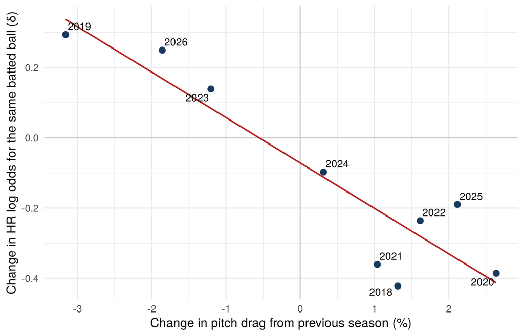

Figure 1: Season-to-season change in the drag of pitched four-seam fastballs against the change in batted-ball carry (the Bayesian ball effect δ). Each point is a season compared with the season before.

```r
ggplot(dc, aes(drag_change, delta)) +
  geom_hline(yintercept = 0, colour = "grey80") +
  geom_vline(xintercept = 0, colour = "grey80") +
  geom_smooth(method = "lm", se = FALSE, colour = red, linewidth = 0.7) +
  geom_point(colour = navy, size = 2.5) +
  geom_text_repel(aes(label = season), size = 3.5, seed = 1) +
  labs(x = "Change in pitch drag from previous season (%)",
       y = "Change in HR log odds for the same batted ball (δ)")
```

In all 9 season-to-season comparisons from 2018 to 2026, pitch drag and batted-ball carry moved in opposite directions, and their correlation is -0.92. When the pitched ball loses speed faster, batted balls with the same exit velocity and launch angle become home runs less often. Two independent measurements of the ball agree, which supports the friend’s view that the ball’s variation is largely one-dimensional: something like $C_d/m$.

## Claims 3 and 4: Mass or drag?

Pitch drag alone cannot tell a heavier ball from a smoother one, since it measures $C_d/m$. But mass also affects the collision with the bat, and collision efficiency gives a second handle. A simple model of the bat–ball collision gives
$$q = \frac{e - r}{1 + r}, \qquad r = \frac{m_{\text{ball}}}{M_{\text{eff}}},$$
where $e$ is the coefficient of restitution and $M_{\text{eff}}$ the effective mass of the bat at the impact point.

```r
e <- 0.50; m_ball <- 0.145; M_eff <- 0.60          # rough, typical values
r0 <- m_ball / M_eff
q0 <- (e - r0) / (1 + r0)
dq_per_pct <- -(1 + e) / (1 + r0)^2 * r0 * 0.01      # change in q per 1% more mass
```

With typical values ($e \approx 0.5$, a 145 g ball, $M_{\text{eff}} \approx 0.6$ kg), this gives $q \approx 0.21$, in line with the measured values. Each 1% increase in ball mass:

- lowers $q$ by about 0.0024, so the ball comes off the bat slower;
- lowers drag deceleration by about 1%, so the ball carries farther.

This gives each kind of change a different signature:

| Change in the ball | Collision efficiency $q$ | Pitch drag $C_d/m$ |
| --- | --- | --- |
| Heavier ball | down | down |
| Higher drag coefficient | unchanged | up |
| Lower coefficient of restitution | down | unchanged |

```r
sig <- tibble(season = c(2025, 2026)) |>
  mutate(dq = sapply(season, function(t) b(t, "q90") - b(t - 1, "q90")),
         dk = sapply(season, function(t)
           100 * (summ$drag_k_mean[summ$season == t] / summ$drag_k_mean[summ$season == t - 1] - 1)),
         mass_implied = -dk,
         dq_if_mass = mass_implied * dq_per_pct)
sig |>
  transmute(Change = paste0(season - 1, "→", season),
            `Observed change in q (90th %ile)` = sprintf("%+.4f", dq),
            `Observed change in pitch drag` = sprintf("%+.1f%%", dk),
            `Mass change if drag were all mass` = sprintf("%+.1f%%", mass_implied),
            `Change in q that mass change predicts` = sprintf("%+.4f", dq_if_mass)) |>
  kable(caption = "Testing the mass explanation: if each season's change in pitch drag were due entirely to ball mass, how much should collision efficiency have changed?")
```

Testing the mass explanation: if each season’s change in pitch drag were due entirely to ball mass, how much should collision efficiency have changed?

| Change | Observed change in q (90th %ile) | Observed change in pitch drag | Mass change if drag were all mass | Change in q that mass change predicts |
| --- | --- | --- | --- | --- |
| 2024→2025 | +0.0006 | +2.1% | -2.1% | +0.0050 |
| 2025→2026 | -0.0055 | -1.9% | +1.9% | -0.0044 |

```r
s25 <- sig |> filter(season == 2025); s26 <- sig |> filter(season == 2026)
```

- **2024 to 2025.** Pitch drag rose 2.1%. If that were all mass, the ball would have been about 2.1% lighter, and collision efficiency should have risen by about 0.0050. It actually changed by only +0.0006. The 2025 change looks like a higher drag coefficient, not a change in mass. It is also the opposite of a heavy ball: a heavier ball would have lowered both exit velocity and drag.
- **2025 to 2026.** Pitch drag fell 1.9%. If that were all mass, the ball would have been about 1.9% heavier, and collision efficiency should have fallen by about 0.0044. It fell by 0.0055. This change matches the heavy-ball signature well, and its size is within MLB’s specification of 5 to 5¼ ounces (about ±2.4% around the midpoint).

So the inertia story is a good description of what happened from 2025 to 2026, as a heavier ball in 2026 or equivalently a lighter one in 2025. It does not fit the change from 2024 to 2025. Over the two years, 2026 ended up with about the same pitch drag as 2024 but lower collision efficiency, which no single factor explains. Mass, drag and restitution probably all vary.

## Summary

| Claim | Verdict |
| --- | --- |
| The 2025 EV rise is mostly the ball, not player turnover | Mostly not turnover: within-batter changes match the league changes. But most of the 2025 bump is faster swings, not the ball. |
| Ball variation is low-dimensional | Supported: pitch drag and batted-ball carry are almost perfectly opposed across nine season changes. |
| Mass works in two directions (lower EV, more carry) | Physically sound, and it fits the 2025→2026 change well. |
| 2025 was a heavy-ball year | Not supported: from 2024, 2025 had higher drag with unchanged collision efficiency. Relative to 2026, the 2025 ball looks lighter. |

## Caveats

- **Air density.** The pitch drag measure includes air density, which depends on weather, altitude and roofs. Season averages over all parks are fairly stable, but a hot or cold season would shift them.
- **Trajectory fits and tracking systems.** Drag comes from Statcast’s fitted trajectories, and the switch from TrackMan to Hawk-Eye in 2020 may have changed how accelerations are estimated. The comparisons are safest within 2021–2026.
- **The collision model is rough.** The predicted change in $q$ per percent of mass depends on the assumed coefficient of restitution and effective bat mass, and the measured $q$ uses an approximate pitch speed at the plate.
- **Bat speed is measured too.** A calibration change in bat tracking could look like a change in collision efficiency.
- **Season averages hide within-season changes.** Balls are made in batches, so mass and drag could change during a season.

## Next steps

The natural extension is to estimate pitch drag and collision efficiency **by month**, with uncertainty, and put them in a joint model with the batted-ball carry. With three measurements (exit velocity given bat speed, pitch drag, and carry given launch conditions) and three unknowns (mass, drag coefficient, restitution), the components might be separately identified. Combined with the day-by-day Bayesian updating, that would show within a few weeks of a new season whether the ball has changed, and how.